# Regression Beyond the Mean Worksheet, Part 2 of 2 (Lec 4)

```r
suppressPackageStartupMessages(library(tidyverse))
suppressPackageStartupMessages(library(broom))
suppressPackageStartupMessages(library(quantreg))  # For quantile regression
suppressPackageStartupMessages(library(testthat))
```

[(Link to Part 1 of the Worksheet)](https://ubc-mds.github.io/DSCI_562/lec3/worksheet.nb.html)

We will continue working with the flu data and horeshoe crab data:

```r
flu <- read_csv("../data/flu-train.csv") %>%
    select(positive = PERCENT_POSITIVES, week = WEEK, year = YEAR)
head(flu)
```

| positive | week | year |
| --- | --- | --- |
| 0.000000000 | 40 | 1997 |
| 0.000000000 | 41 | 1997 |
| 0.002577320 | 42 | 1997 |
| 0.000000000 | 43 | 1997 |
| 0.004744333 | 44 | 1997 |
| 0.000000000 | 45 | 1997 |

```r
crab <- read_table("https://newonlinecourses.science.psu.edu/stat504/sites/onlinecourses.science.psu.edu.stat504/files/lesson07/crab/index.txt",
                   col_names = FALSE) %>%
  select(-1) %>%
  setNames(c("colour","spine","width","weight","n_male")) %>%
  mutate(colour = factor(colour),
         spine  = factor(spine))
head(crab)
```

| colour | spine | width | weight | n_male |
| --- | --- | --- | --- | --- |
| 2 | 3 | 28.3 | 3.05 | 8 |
| 3 | 3 | 26.0 | 2.60 | 4 |
| 3 | 3 | 25.6 | 2.15 | 0 |
| 4 | 2 | 21.0 | 1.85 | 0 |
| 2 | 3 | 29.0 | 3.00 | 1 |
| 1 | 2 | 25.0 | 2.30 | 3 |

## Quantile Regression as an Optimization Problem

(Useful when we have an assumption on the model function, but NOT a distributional assumption).

Use the horseshoe crab data again to fit a linear 0.75-quantile regression model. Use the `quantreg::rq()` function.

```r
crab_rq <- rq(n_male ~ width, data = crab, tau = 0.75)
crab_rq
```

```
Call:
rq(formula = n_male ~ width, tau = 0.75, data = crab)

Coefficients:
(Intercept)       width
-10.1142857   0.5714286

Degrees of freedom: 173 total; 171 residual
```

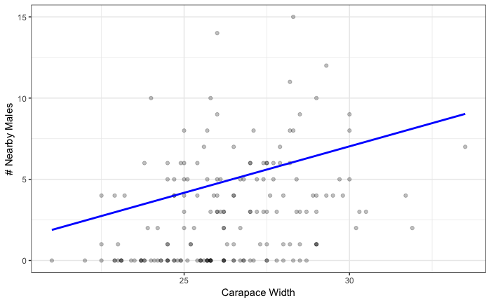

```r
crab <- crab %>%
    mutate(q75_rq = predict(crab_rq))
p_crab <- ggplot(crab, aes(width, n_male)) +
    geom_point(alpha = 0.25) +
    theme_bw() +
    labs(x = "Carapace Width",
         y = "# Nearby Males")
p_crab +
    geom_line(aes(y = q75_rq), colour = "blue", size = 1)
```

Use `ggplot2::geom_quantile()` to plot a 90% prediction band. (Notice the problem for small quantiles here – linear is probably just not a good assumption!)

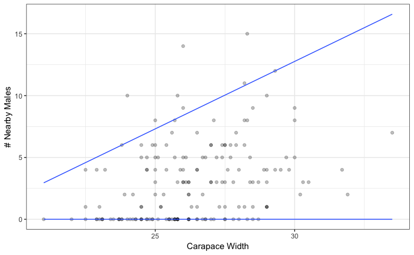

## Error Calculation

Calculate the error of the 0.75-quantile regression model here. First, we’ll define the error function.

| score_rq |
| --- |
| 1.042816 |

## Probabilistic Forecasting

### Local Method

We’ll use the flu data to produce a predictive distribution for “percent positives” (column `positive`) on Week 10, under various assumption frameworks.

First, let’s not assume anything along the predictor space, and use a local method for estimation. Specifically, let’s use a “moving window” approach, using a two week radius.

1. Display the predictive distribution as a density function, using two models: one without assuming any distribution, and another assuming a Gaussian.

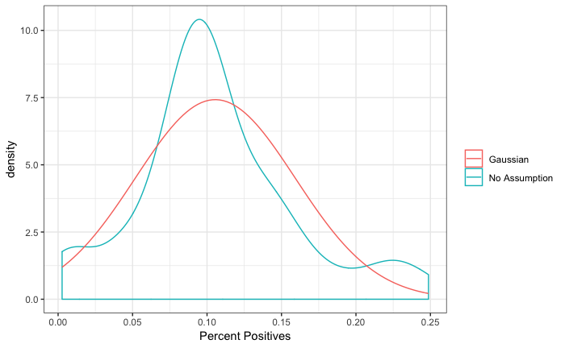

2. Produce a predictive distribution as a cdf instead of a density.

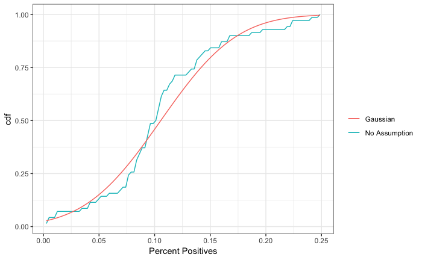

### Distributional assumption with additional assumptions on parameters

Recall assuming a Poisson distribution for the crab data (`Y|X=x`), whose mean is exponential in `x`:

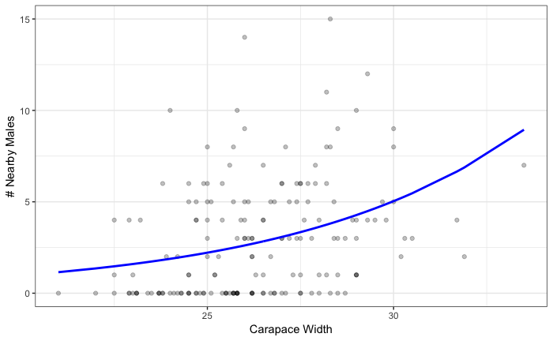

```r
crab <- glm(n_male ~ width, data = crab, family = poisson) %>%
    augment(type.predict = "response") %>%
    select(n_male, width, mean = .fitted)
p_crab <- ggplot(crab, aes(width, n_male)) +
    geom_point(alpha = 0.25) +
    theme_bw() +
    labs(x = "Carapace Width",
         y = "# Nearby Males")
p_crab +
    geom_line(aes(y = mean), colour = "blue", size = 1)
```

Use this model to produce a probabilistic forecast for `n_male` at `width=25`.

```r
(mean_at_25 <- crab %>%
     filter(width == 25) %>%
     summarize(unique(mean)) %>%
     .[[1]])
```

```
[1] 2.217477
```

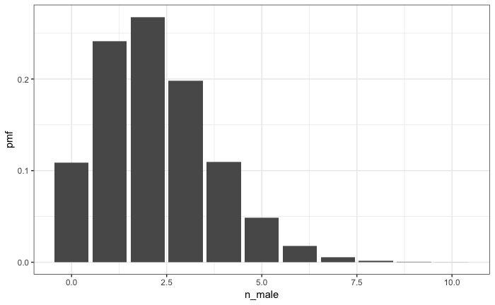

```r
pmf <- tibble(
    n_male = 0:10,
    pmf    = dpois(n_male, lambda = mean_at_25)
)
ggplot(pmf, aes(n_male, pmf)) +
    geom_col() +
    theme_bw()
```

Is the Poisson assumption good? Try the following three options:

1. Generate data under the assumed model and the `width` values that come with the data. Compare the scatterplot to the actual scatterplot.

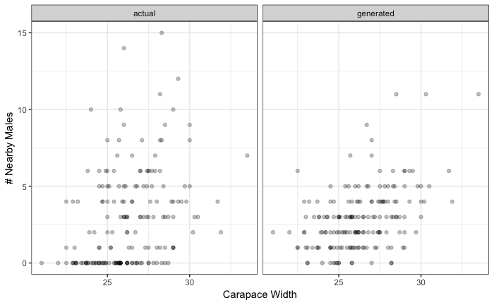

2. BONUS: Check the calibration of the pmf at width=25: plot the observed nearby points under the pmf.
3. BONUS: calculate the PIT scores of all observations. Are they Unif(0,1)?